# Problem Set 8

Due date: 20 November

**Kennedy Lighty**

```r
library(tidyverse)
library(fitzRoy)
library(broom)
library(modelsummary)
library(ggdist)
library(ggplot2)
library(knitr)
```

Please upload your completed assignment to the ELMs course site (under the assignments menu). Remember to include an annotated script file for all work with R and show your math for all other problems (if applicable, or necessary). Please also upload your completed assignment to the Github repository that you have shared with us. *We should be able to run your script with no errors.*

**Total points: 30**

## Question 1

*Points: 5*

**Note**

5/5

For the following regression equation, $\hat{Y} = 8.5 + 6x + \epsilon$, the standard error for $\beta_0$ is 2.5, the standard error for $\beta_1$ is 3.5, and the sample size is 2000. Find the t-statistic, 95% confidence interval, and p-value (using a two-tailed test) for $\beta_1$.

Is $\beta_1$ statistically significant at the 0.05-level with a two-tailed test? Why or why not?

**The t-statistic is 1.71, the 95% confidence interval is [−0.86, 12.86], and the P value is 0.087. This is not statistically significant because the P-value is greater than 0.05.**

## Question 2

*Points: 5*

**Note**

5/5

Suppose you estimate an OLS regression and retrieve a $R^2$ value of 0.45. If the Total Sum of Squares (TSS) from that regression equals 4,700, what is the value for the Residual Sum of Squares (RSS)?

```r
4700 * (1-0.45)
```

```
[1] 2585
```

**The value for the RSS is 2,585.**

## Question 3

*Points: 5*

**Note**

5/5

Suppose you estimate a bivariate regression with a sample size of 102 and obtain a regression coefficient ($\beta_1$) of 5.0. What is the largest standard error that $\beta_1$ could have and still be statistically significant (i.e., reject the null hypothesis of no relationship) at the 0.05 level with a one-tailed test?

```r
5.0/1.660
```

```
[1] 3.012048
```

**The largest standard error that is also statistically significant is 3.01.**

## Question 4

*Points: 5*

**Note**

4/5

```r
gapminder_df <- wbstats::wb_data(c("NY.GDP.PCAP.CD", "SP.DYN.LE00.IN"),
                                 start_date = 2019, end_date = 2019) |>
  dplyr::rename(gdp_per_cap = "NY.GDP.PCAP.CD", life_exp = "SP.DYN.LE00.IN")
```

Using the `gapminder_df` data set read in above, produce a scatterplot of the variables `gdp_per_cap` and `life_exp` (with `life_exp` as the dependent variable on the y-axis). Fit a regression line to the scatterplot. Describe the relationship illustrated. Note any suspected outliers, if any (a visual inspection will suffice for this question).

**Note**

The variable `gdp_per_cap` measures each country’s GDP per capita (representing their individual wealth), and `life_exp` indicates the number of years individuals within that country born that year are expected to live (representing their health).

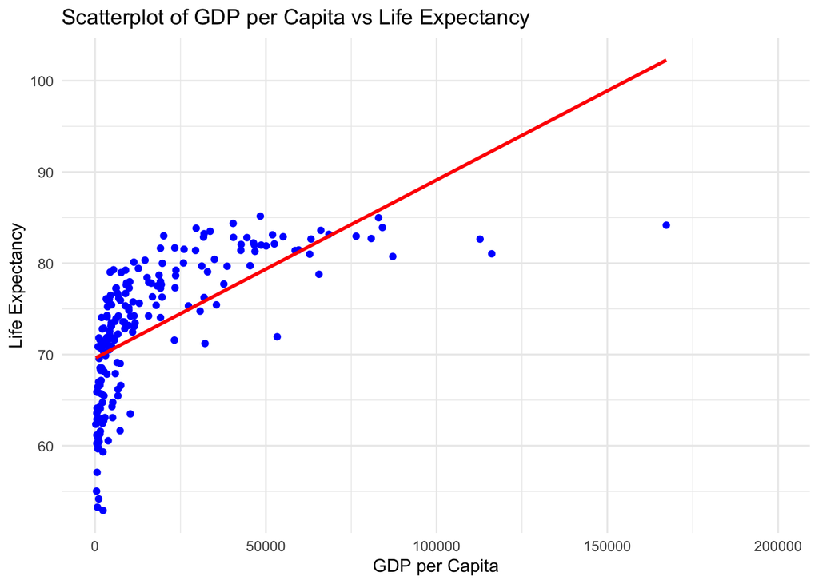

```r
ggplot(gapminder_df, aes(x = gdp_per_cap, y = life_exp)) +
  geom_point(color = "blue") +
  geom_smooth(method = "lm", color = "red", se = FALSE) +
  labs(
    title = "Scatterplot of GDP per Capita vs Life Expectancy",
    x = "GDP per Capita",
    y = "Life Expectancy"
  ) +
  theme_minimal()
```

**The plot shows the relationship between GDP per capita and life expectancy. This would suggest that as GDP increases so does life expectancy. There are a few outliers.**

**Note**

I need more detail about which points could be outliers and why.

## Question 5

*Points: 10*

**Note**

7/10

Estimate a bivariate regression with `life_exp` as the dependent variable and `gdp_per_cap` as the independent variable and report the results in a professionally formatted table. In as much detail as possible, describe (and interpret) the regression results.

```r
gapminder_df <- data.frame(
  gdp_per_cap = c(1000, 2000, 3000, 4000, 5000, 6000, 7000, 8000, 9000, 10000),
  life_exp = c(55, 58, 61, 65, 67, 70, 73, 75, 78, 80)
)

model <- lm(life_exp ~ gdp_per_cap, data = gapminder_df)

regression_results <- tidy(model, conf.int = TRUE)

colnames(regression_results) <- c("Term", "Estimate", "Std. Error", "t-value", "p-value", "Conf.Low", "Conf.High")

kable(
  regression_results,
  caption = "Bivariate Regression Results: Life Expectancy vs GDP per Capita",
  digits = 3
)
```

Bivariate Regression Results: Life Expectancy vs GDP per Capita

| Term | Estimate | Std. Error | t-value | p-value | Conf.Low | Conf.High |
| --- | --- | --- | --- | --- | --- | --- |
| (Intercept) | 52.800 | 0.404 | 130.646 | 0 | 51.868 | 53.732 |
| gdp_per_cap | 0.003 | 0.000 | 42.988 | 0 | 0.003 | 0.003 |

**The positive coefficient for GDP per capita suggests a strong positive relationship between higher income levels being associated with longer life expectancy.**

**Note**

Better to use the logged form of GDP per capita.

You can be more specific about this relationship. What change in Y is a one unit increase in X associated with, on average? What is the predicted value for an observation with X = 0?

Professionally formatted tables have more friendly variable labels.